# PCA & clustering

### Problem Statement:-

- Perform Principal component analysis and perform clustering using first 3 principal component scores (both heirarchial and k mean clustering(scree plot or elbow curve) and obtain optimum number of clusters and check whether we have obtained same number of clusters with the original data (class column we have ignored at the begining who shows it has 3 clusters)

### Data Understanding and Preparation

```r
#Reading the dataset
library(readxl)
univ <- read_excel("~/desktop/Digi 360/Module 14/University_Clustering.xlsx")
```

| Univ | State | SAT | Top10 | Accept | SFRatio | Expenses | GradRate |
| --- | --- | --- | --- | --- | --- | --- | --- |
| Brown | RI | 1310 | 89 | 22 | 13 | 22704 | 94 |
| CalTech | CA | 1415 | 100 | 25 | 6 | 63575 | 81 |
| CMU | PA | 1260 | 62 | 59 | 9 | 25026 | 72 |
| Columbia | NY | 1310 | 76 | 24 | 12 | 31510 | 88 |
| Cornell | NY | 1280 | 83 | 33 | 13 | 21864 | 90 |
| Dartmouth | NH | 1340 | 89 | 23 | 10 | 32162 | 95 |

```r
any(is.na(univ))
```

```
[1] FALSE
```

```r
#Removing First column since it is categorical
univ_num <- univ[, -c(1,2)]
head(univ_num)
```

| SAT | Top10 | Accept | SFRatio | Expenses | GradRate |
| --- | --- | --- | --- | --- | --- |
| 1310 | 89 | 22 | 13 | 22704 | 94 |
| 1415 | 100 | 25 | 6 | 63575 | 81 |
| 1260 | 62 | 59 | 9 | 25026 | 72 |
| 1310 | 76 | 24 | 12 | 31510 | 88 |
| 1280 | 83 | 33 | 13 | 21864 | 90 |
| 1340 | 89 | 23 | 10 | 32162 | 95 |

```r
summary(univ_num)
```

```
      SAT           Top10            Accept        SFRatio         Expenses
 Min.   :1005   Min.   : 28.00   Min.   :14.0   Min.   : 6.00   Min.   : 8704
 1st Qu.:1240   1st Qu.: 74.00   1st Qu.:24.0   1st Qu.:11.00   1st Qu.:15140
 Median :1285   Median : 81.00   Median :36.0   Median :12.00   Median :27553
 Mean   :1266   Mean   : 76.48   Mean   :39.2   Mean   :12.72   Mean   :27388
 3rd Qu.:1340   3rd Qu.: 90.00   3rd Qu.:50.0   3rd Qu.:14.00   3rd Qu.:34870
 Max.   :1415   Max.   :100.00   Max.   :90.0   Max.   :25.00   Max.   :63575
    GradRate
 Min.   :67.00
 1st Qu.:81.00
 Median :90.00
 Mean   :86.72
 3rd Qu.:94.00
 Max.   :97.00
```

### Scaling

Before applying PCA or Clustering, we have to normalize the data so that the scale of each variable is the same. Why is this important? Well, if the scale of the variables is not the same, the model might become biased towards the variables with a higher magnitude.

```r
univ_scaled <- as.data.frame(scale(univ_num))
summary(univ_scaled)
```

```
      SAT              Top10             Accept           SFRatio
 Min.   :-2.4127   Min.   :-2.4946   Min.   :-1.2774   Min.   :-1.6522
 1st Qu.:-0.2440   1st Qu.:-0.1276   1st Qu.:-0.7705   1st Qu.:-0.4229
 Median : 0.1713   Median : 0.2326   Median :-0.1622   Median :-0.1770
 Mean   : 0.0000   Mean   : 0.0000   Mean   : 0.0000   Mean   : 0.0000
 3rd Qu.: 0.6788   3rd Qu.: 0.6957   3rd Qu.: 0.5475   3rd Qu.: 0.3147
 Max.   : 1.3710   Max.   : 1.2103   Max.   : 2.5751   Max.   : 3.0192
    Expenses           GradRate
 Min.   :-1.29526   Min.   :-2.1771
 1st Qu.:-0.84909   1st Qu.:-0.6315
 Median : 0.01144   Median : 0.3621
 Mean   : 0.00000   Mean   : 0.0000
 3rd Qu.: 0.51869   3rd Qu.: 0.8037
 Max.   : 2.50865   Max.   : 1.1349
```

Since all the values here are continuous numerical values, you will use the euclidean distance method.

```r
nrow(univ_scaled)
```

```
[1] 25
```

### Cluster Tendency with Hopkins Statistic

```r
library(factoextra)
library(ggplot2)
# Compute Hopkins statistic for iris dataset
res <- get_clust_tendency(univ_scaled, n = 24, graph = FALSE)
res$hopkins_stat
```

```
[1] 0.6660269
```

Since hopkins is above the threshold, our data is tendency to clustering.

### Elbow Curve

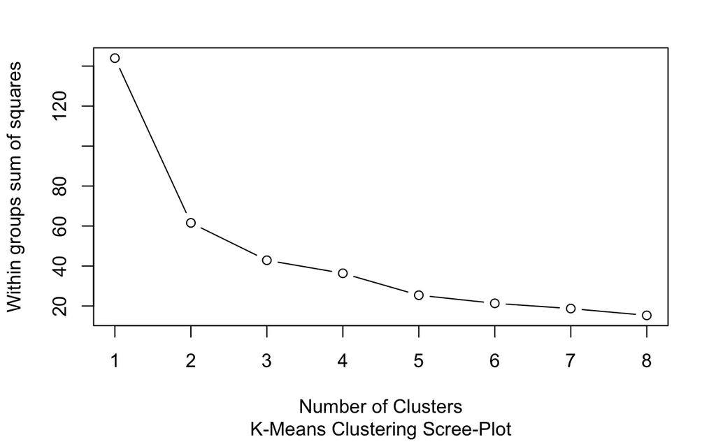

```r
wss = (nrow(univ_scaled)-1)*sum(apply(univ_scaled, 2, var))      # Determine number of clusters by scree-plot
for (i in 1:8) wss[i] = sum(kmeans(univ_scaled, centers=i)$withinss)
plot(1:8, wss, type="b", xlab="Number of Clusters", ylab="Within groups sum of squares")   # Look for an "elbow" in the scree plot #
title(sub = "K-Means Clustering Scree-Plot")
```

### Building the Model

```r
model <- kmeans(univ_scaled, 3) # 3 cluster solution
str(model)
```

```
List of 9
 $ cluster     : int [1:25] 2 3 2 2 2 3 3 2 3 3 ...
 $ centers     : num [1:3, 1:6] -1.8913 -0.0364 0.8891 -1.9415 0.1039 ...
  ..- attr(*, "dimnames")=List of 2
  .. ..$ : chr [1:3] "1" "2" "3"
  .. ..$ : chr [1:6] "SAT" "Top10" "Accept" "SFRatio" ...
 $ totss       : num 144
 $ withinss    : num [1:3] 7.09 21.38 14.29
 $ tot.withinss: num 42.8
 $ betweenss   : num 101
 $ size        : int [1:3] 4 12 9
 $ iter        : int 2
 $ ifault      : int 0
 - attr(*, "class")= chr "kmeans"
```

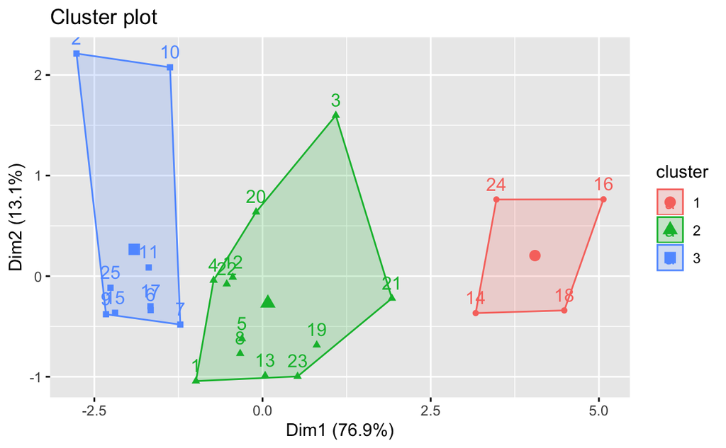

```r
fviz_cluster(model, data = univ_scaled)
```

### Applying PCA

```r
pcaObj<-princomp(univ_scaled, cor = TRUE, scores = TRUE, covmat = NULL)
```

```r
summary(pcaObj)
```

```
Importance of components:
                          Comp.1    Comp.2     Comp.3     Comp.4    Comp.5
Standard deviation     2.1475766 0.8870266 0.53531473 0.40469755 0.3525708
Proportion of Variance 0.7686808 0.1311360 0.04776031 0.02729668 0.0207177
Cumulative Proportion  0.7686808 0.8998169 0.94757718 0.97487386 0.9955916
                            Comp.6
Standard deviation     0.162636495
Proportion of Variance 0.004408438
Cumulative Proportion  1.000000000
```

```r
loadings(pcaObj)
```

```
Loadings:
         Comp.1 Comp.2 Comp.3 Comp.4 Comp.5 Comp.6
SAT       0.458         0.187  0.131         0.858
Top10     0.427 -0.200  0.498  0.375  0.482 -0.396
Accept   -0.424  0.321 -0.156         0.801  0.217
SFRatio  -0.391 -0.433  0.606 -0.507         0.172
Expenses  0.363  0.634  0.205 -0.623        -0.174
GradRate  0.379 -0.516 -0.532 -0.439  0.338

               Comp.1 Comp.2 Comp.3 Comp.4 Comp.5 Comp.6
SS loadings     1.000  1.000  1.000  1.000  1.000  1.000
Proportion Var  0.167  0.167  0.167  0.167  0.167  0.167
Cumulative Var  0.167  0.333  0.500  0.667  0.833  1.000
```

[figure not shown]

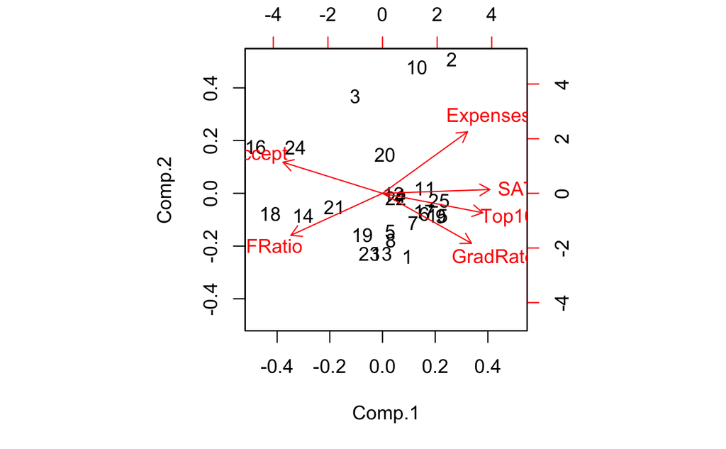

```r
biplot(pcaObj)
```

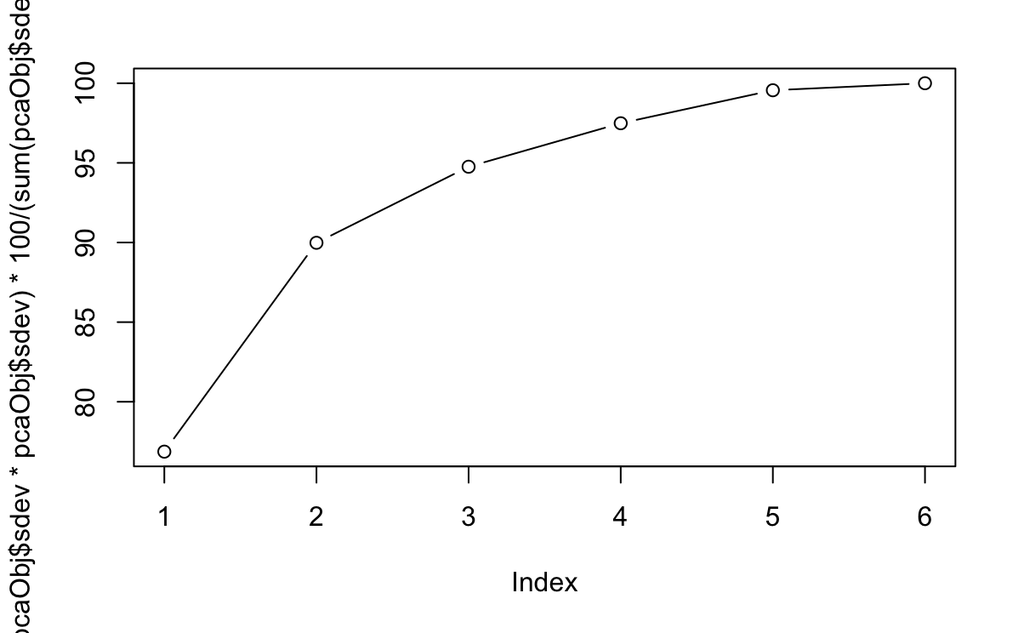

```r
plot(cumsum(pcaObj$sdev*pcaObj$sdev)*100/(sum(pcaObj$sdev*pcaObj$sdev)),type="b")
```

```r
pcaObj$scores
```

```
           Comp.1      Comp.2      Comp.3      Comp.4      Comp.5       Comp.6
 [1,]  1.00987445 -1.06430962  0.08106631  0.05695064 -0.12875425 -0.034649638
 [2,]  2.82223781  2.25904458  0.83682883  0.14384464 -0.12596191 -0.180703168
 [3,] -1.11246577  1.63120889 -0.26678684  1.07507502 -0.19181415  0.345679459
 [4,]  0.74174122 -0.04218747  0.06050086 -0.15720812 -0.57761139  0.109163092
 [5,]  0.31191206 -0.63524357  0.01024052  0.17136367  0.01272613 -0.016921270
 [6,]  1.69669089 -0.34436328 -0.25340751  0.01256433 -0.05266060 -0.027166160
 [7,]  1.24682093 -0.49098366 -0.03209382 -0.20564378  0.29350534 -0.078011984
 [8,]  0.33874978 -0.78516859 -0.49358483  0.03985631 -0.54497862 -0.155371653
 [9,]  2.37415013 -0.38653888  0.11609839 -0.45336562 -0.23010830  0.266983932
[10,]  1.40327739  2.11951503 -0.44282714 -0.63254327  0.23005353 -0.235615124
[11,]  1.72610332  0.08823712  0.17040366  0.26090191  0.23331838  0.238968449
[12,]  0.45085748 -0.01113295 -0.17574605  0.23616563  0.26325070 -0.314843521
[13,] -0.04023814 -1.00920438 -0.49651717  0.22929876  0.44803192  0.004939215
[14,] -3.23373034 -0.37458049 -0.49537282 -0.52123771 -0.63929481 -0.090047785
[15,]  2.23626502 -0.37179329 -0.39899365  0.40696648 -0.41676068  0.050618633
[16,] -5.17299212  0.77991535 -0.38591233 -0.23221171  0.17928698 -0.030904694
[17,]  1.69964377 -0.30559745  0.31850785 -0.29746268 -0.16342468  0.114422592
[18,] -4.57814600 -0.34759136  1.49964176 -0.45425171 -0.19114197  0.104149297
[19,] -0.82260312 -0.69890615  1.42781145  0.76077880  0.18426033 -0.251103268
[20,]  0.09776213  0.65044645  0.10050844 -0.50009719  0.48721782  0.219242132
[21,] -1.96318260 -0.22476756 -0.25588143 -0.04847410  0.82274566  0.152246521
[22,]  0.54228894 -0.07958884 -0.30539348  0.13169876  0.05273991 -0.036726444
[23,] -0.53222092 -1.01716720 -0.42371636  0.16953571  0.35781321 -0.066098999
[24,] -3.54869664  0.77846167 -0.44936332  0.32367862 -0.35833256 -0.077456415
[25,]  2.30590032 -0.11770432  0.25398866 -0.51618337  0.05589401 -0.010793201
```

```r
pcaObj$scores[,1:3]
```

```
           Comp.1      Comp.2      Comp.3
 [1,]  1.00987445 -1.06430962  0.08106631
 [2,]  2.82223781  2.25904458  0.83682883
 [3,] -1.11246577  1.63120889 -0.26678684
 [4,]  0.74174122 -0.04218747  0.06050086
 [5,]  0.31191206 -0.63524357  0.01024052
 [6,]  1.69669089 -0.34436328 -0.25340751
 [7,]  1.24682093 -0.49098366 -0.03209382
 [8,]  0.33874978 -0.78516859 -0.49358483
 [9,]  2.37415013 -0.38653888  0.11609839
[10,]  1.40327739  2.11951503 -0.44282714
[11,]  1.72610332  0.08823712  0.17040366
[12,]  0.45085748 -0.01113295 -0.17574605
[13,] -0.04023814 -1.00920438 -0.49651717
[14,] -3.23373034 -0.37458049 -0.49537282
[15,]  2.23626502 -0.37179329 -0.39899365
[16,] -5.17299212  0.77991535 -0.38591233
[17,]  1.69964377 -0.30559745  0.31850785
[18,] -4.57814600 -0.34759136  1.49964176
[19,] -0.82260312 -0.69890615  1.42781145
[20,]  0.09776213  0.65044645  0.10050844
[21,] -1.96318260 -0.22476756 -0.25588143
[22,]  0.54228894 -0.07958884 -0.30539348
[23,] -0.53222092 -1.01716720 -0.42371636
[24,] -3.54869664  0.77846167 -0.44936332
[25,]  2.30590032 -0.11770432  0.25398866
```

```r
# Top 3 pca scores
final<-cbind(univ[,1:2],pcaObj$scores[,1:3])
View(final)
```

### K- Means Clustering

```r
model <- kmeans(pcaObj$scores[,1:3], 3) # 3 cluster solution
str(model)
```

```
List of 9
 $ cluster     : int [1:25] 3 1 3 3 3 1 1 3 1 1 ...
 $ centers     : num [1:3, 1:3] 1.9457 -4.1334 -0.0815 0.2722 0.2091 ...
  ..- attr(*, "dimnames")=List of 2
  .. ..$ : chr [1:3] "1" "2" "3"
  .. ..$ : chr [1:3] "Comp.1" "Comp.2" "Comp.3"
 $ totss       : num 142
 $ withinss    : num [1:3] 13.1 6.57 18.14
 $ tot.withinss: num 37.8
 $ betweenss   : num 104
 $ size        : int [1:3] 9 4 12
 $ iter        : int 2
 $ ifault      : int 0
 - attr(*, "class")= chr "kmeans"
```

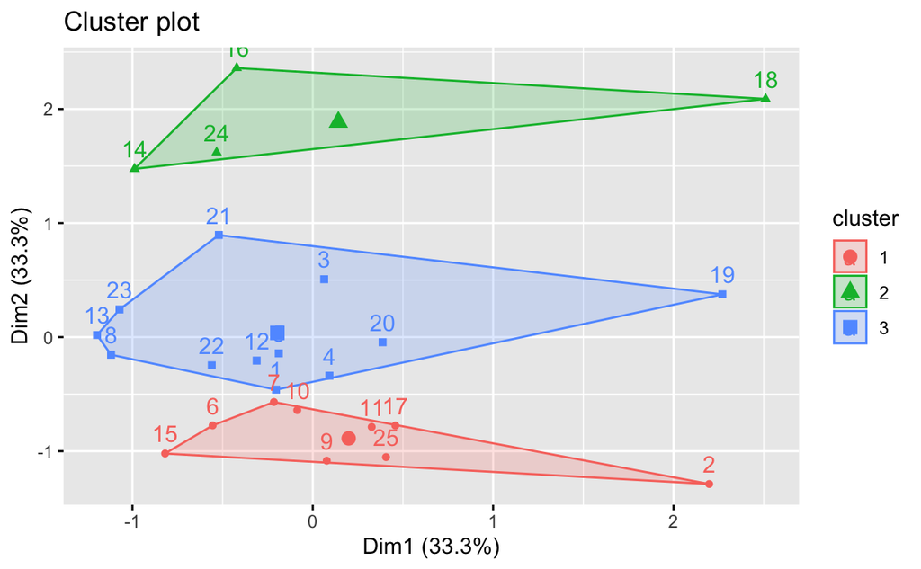

```r
fviz_cluster(model, data = pcaObj$scores[,1:3])
```

```r
#Appending the clusters to original dataframe.
suppressPackageStartupMessages(library(dplyr))
univ_cl <- mutate(univ, model$cluster)
```

```r
head(univ_cl)
```

| Univ | State | SAT | Top10 | Accept | SFRatio | Expenses | GradRate | model$cluster |
| --- | --- | --- | --- | --- | --- | --- | --- | --- |
| Brown | RI | 1310 | 89 | 22 | 13 | 22704 | 94 | 3 |
| CalTech | CA | 1415 | 100 | 25 | 6 | 63575 | 81 | 1 |
| CMU | PA | 1260 | 62 | 59 | 9 | 25026 | 72 | 3 |
| Columbia | NY | 1310 | 76 | 24 | 12 | 31510 | 88 | 3 |
| Cornell | NY | 1280 | 83 | 33 | 13 | 21864 | 90 | 3 |
| Dartmouth | NH | 1340 | 89 | 23 | 10 | 32162 | 95 | 1 |

### Visualizing few attributes

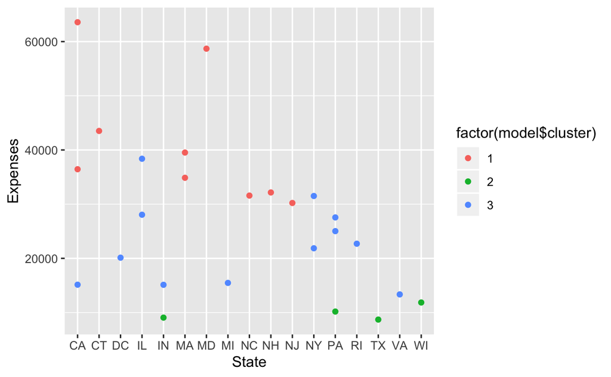

```r
suppressPackageStartupMessages(library(ggplot2))
ggplot(univ_cl, aes(x=State, y = Expenses, color = factor(model$cluster))) + geom_point()
```

```r
univ_num <- univ_num %>%
  mutate(Cluster = model$cluster) %>%
  group_by(Cluster) %>%
  summarise_all("mean")
```

```r
head(univ_num)
```

| Cluster | SAT | Top10 | Accept | SFRatio | Expenses | GradRate |
| --- | --- | --- | --- | --- | --- | --- |
| 1 | 1362.778 | 90.55556 | 24.33333 | 9.666667 | 41176.89 | 92.22222 |
| 2 | 1061.500 | 38.75000 | 70.00000 | 19.250000 | 9953.00 | 71.75000 |
| 3 | 1262.500 | 78.50000 | 40.08333 | 12.833333 | 22858.00 | 87.58333 |

```r
#Writing the final file with assigned cluster IDs.
write.csv(univ_cl, file="~/desktop/Digi 360/Module 14/University_final_R.csv")
```

### Hierarchical clustering

```r
dist_mat <- dist(pcaObj$scores[,1:3], method = 'euclidean')
hclust_ward <- hclust(dist_mat, method = 'ward.D2')
```

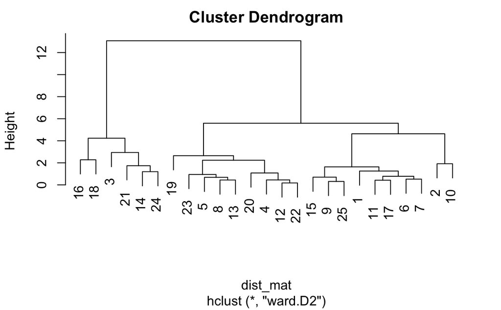

```r
#Plotting the dendrogram
plot(hclust_ward)
```

```r
#cutting the dendrogram
cut_ward <- cutree(hclust_ward, k = 3)
```

```r
plot(hclust_ward)
rect.hclust(hclust_ward , k = 3, border = 2:6)
```

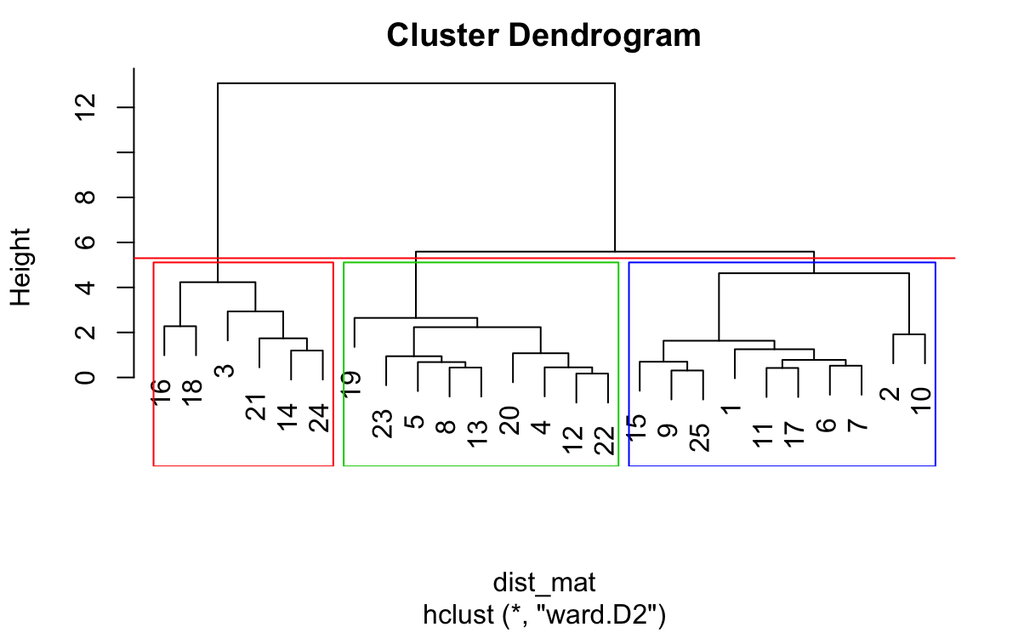

```r
abline(h = 5.3, col = 'red')
```

Let’s visualize the tree with different colored branches using package `dendextend`

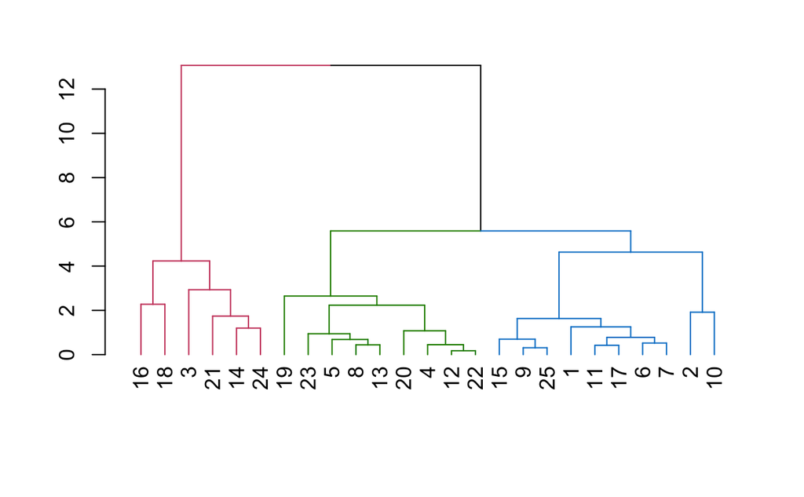

```r
suppressPackageStartupMessages(library(dendextend))
ward_dend_obj <- as.dendrogram(hclust_ward)
ward_col_dend <- color_branches(ward_dend_obj, h = 5.3)
plot(ward_col_dend)
```

```r
#Appending the clusters to original dataframe.
suppressPackageStartupMessages(library(dplyr))
univ_cl <- mutate(univ, cluster = cut_ward)
```

```r
#Writing the final file with assigned cluster IDs.
write.csv(univ_cl, file="~/desktop/Digi 360/Module 14/univ_final_R.csv")
```

### Conclusion

- With PCA, we could see that same number of clusters formed that are formed without PCA.